# AKPopMap

Courtney Hart

11/8/2019

```r
library(sf)
library(dplyr)
```

```r
library(ggplot2)
library(scales)
```

# Prepare Regions Shapefile

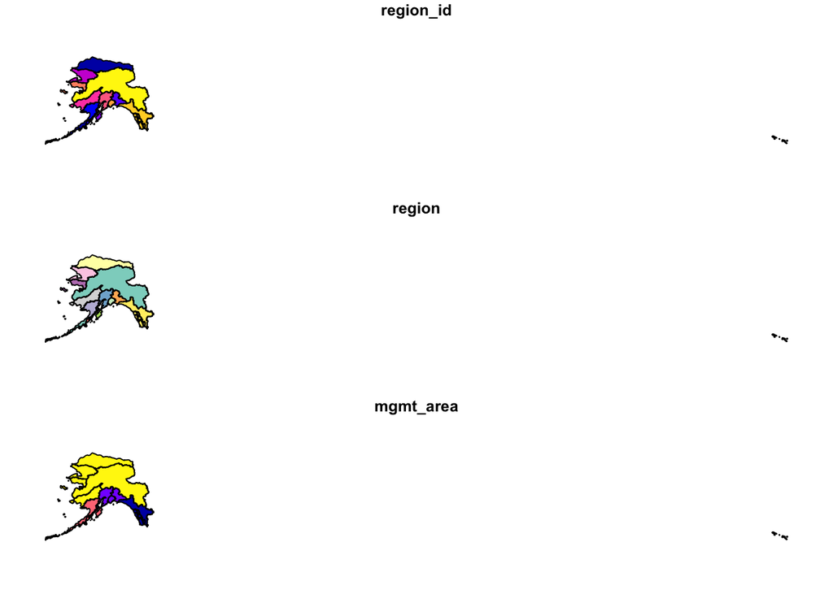

```r
ak_regions <- read_sf("data/Shapefiles/ak_regions_simp.shp")

plot(ak_regions) # something wrong with peninsula
```

```r
st_crs(ak_regions) #checks out what projection is being used, it's unprojected
```

```
## Coordinate Reference System:
##   EPSG: 4326
##   proj4string: "+proj=longlat +datum=WGS84 +no_defs"
```

```r
class(ak_regions) # lists features class
```

```
## [1] "sf"         "tbl_df"     "tbl"        "data.frame"
```

An SF obejct is a data frame and work well with TidyVerse. We can also use pipes

coordinate transformations

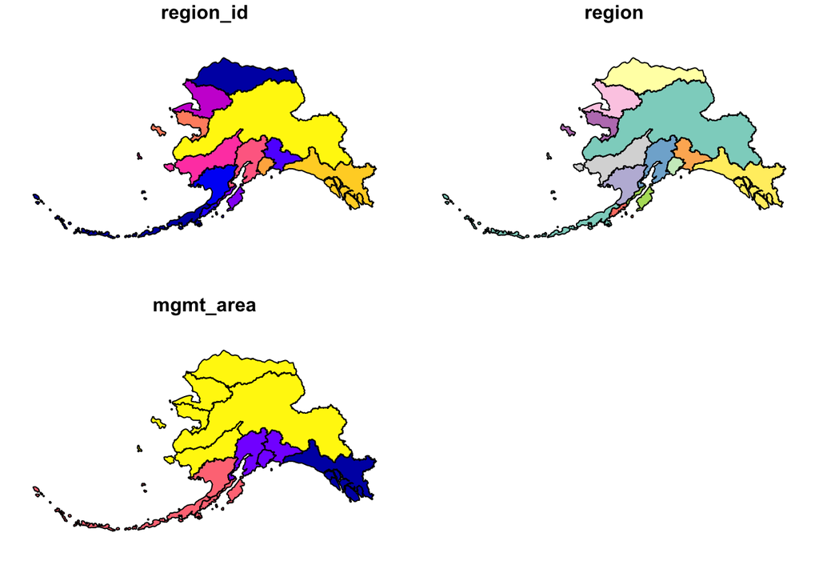

```r
ak_regions_3338 <- ak_regions %>%
  st_transform(crs = 3338)

plot(ak_regions_3338)
```

```r
summary(ak_regions_3338)
```

```
##    region_id     region            mgmt_area          geometry
##  Min.   : 1   Length:13          Min.   :1   MULTIPOLYGON :13
##  1st Qu.: 4   Class :character   1st Qu.:2   epsg:3338    : 0
##  Median : 7   Mode  :character   Median :3   +proj=aea ...: 0
##  Mean   : 7                      Mean   :3
##  3rd Qu.:10                      3rd Qu.:4
##  Max.   :13                      Max.   :4
```

Geometry column is sticky and will stay ‘connected’ to the othere features in the dataframe

```r
ak_regions_3338 %>%
  select(region)
```

```
## Simple feature collection with 13 features and 1 field
## geometry type:  MULTIPOLYGON
## dimension:      XY
## bbox:           xmin: -2175328 ymin: 405653.9 xmax: 1579226 ymax: 2383770
## epsg (SRID):    3338
## proj4string:    +proj=aea +lat_1=55 +lat_2=65 +lat_0=50 +lon_0=-154 +x_0=0 +y_0=0 +ellps=GRS80 +towgs84=0,0,0,0,0,0,0 +units=m +no_defs
## # A tibble: 13 x 2
##    region                                                          geometry
##    <chr>                                                 <MULTIPOLYGON [m]>
##  1 Aleutian Islands (((-1156666 420855.1, -1159837 417990.3, -1161898 4169…
##  2 Arctic           (((571289.9 2143072, 569941.5 2142691, 569158.2 214214…
##  3 Bristol Bay      (((-339688.6 973904.9, -339302 972297.3, -339229.2 971…
##  4 Chignik          (((-114381.9 649966.8, -112866.8 652065.8, -108836.8 6…
##  5 Copper River     (((561012 1148301, 559393.7 1148169, 557797.7 1148492,…
##  6 Kodiak           (((115112.5 983293, 113051.3 982825.9, 110801.3 983211…
##  7 Kotzebue         (((-678815.3 1819519, -677555.2 1820698, -675557.8 182…
##  8 Kuskokwim        (((-1030125 1281198, -1029858 1282333, -1028980 128403…
##  9 Cook Inlet       (((35214.98 1002457, 36660.3 1002038, 36953.11 1001186…
## 10 Norton Sound     (((-848357 1636692, -846510 1635203, -840513.7 1632225…
## 11 Prince William … (((426007.1 1087250, 426562.5 1088591, 427711.6 108999…
## 12 Southeast        (((1287777 744574.1, 1290183 745970.8, 1292940 746262.…
## 13 Yukon            (((-375318 1473998, -373723.9 1473487, -373064.8 14739…
```

# Prepare Population data

```r
pop <- read.csv("data/Shapefiles/alaska_population.csv",
                stringsAsFactors = F)

class(pop)
```

```
## [1] "data.frame"
```

Coerce to sf object using ‘st_as_sf’

```r
pop_4326 <- st_as_sf(pop,
                     coords = c("lng", "lat"),  # this is what coords are removed
                                                # lat/long colums and set to geometry
                     crs = 4326) #this is what CRS we HAVE, not what we have

st_crs(pop_4326)
```

```
## Coordinate Reference System:
##   EPSG: 4326
##   proj4string: "+proj=longlat +datum=WGS84 +no_defs"
```

```r
head(pop_4326)
```

```
## Simple feature collection with 6 features and 3 fields
## geometry type:  POINT
## dimension:      XY
## bbox:           xmin: -176.6581 ymin: 51.88 xmax: -154.1703 ymax: 62.68889
## epsg (SRID):    4326
## proj4string:    +proj=longlat +datum=WGS84 +no_defs
##   year     city population                   geometry
## 1 2015     Adak        122    POINT (-176.6581 51.88)
## 2 2015   Akhiok         84 POINT (-154.1703 56.94556)
## 3 2015 Akiachak        562 POINT (-161.4314 60.90944)
## 4 2015    Akiak        399 POINT (-161.2139 60.91222)
## 5 2015   Akutan        899 POINT (-165.7731 54.13556)
## 6 2015 Alakanuk        777 POINT (-164.6153 62.68889)
```

dataframes are still in different coordinate systems, convert pop to 3338

```r
pop_3338 <- pop_4326 %>%
  st_transform(crs = 3338)
```

# Calculate population by region

```r
pop_joined <- st_join(pop_3338, ak_regions_3338, join = st_within)

head(pop_joined)
```

```
## Simple feature collection with 6 features and 6 fields
## geometry type:  POINT
## dimension:      XY
## bbox:           xmin: -1537925 ymin: 472627.8 xmax: -10340.71 ymax: 1456223
## epsg (SRID):    3338
## proj4string:    +proj=aea +lat_1=55 +lat_2=65 +lat_0=50 +lon_0=-154 +x_0=0 +y_0=0 +ellps=GRS80 +towgs84=0,0,0,0,0,0,0 +units=m +no_defs
##   year     city population region_id           region mgmt_area
## 1 2015     Adak        122         1 Aleutian Islands         3
## 2 2015   Akhiok         84         6           Kodiak         3
## 3 2015 Akiachak        562         8        Kuskokwim         4
## 4 2015    Akiak        399         8        Kuskokwim         4
## 5 2015   Akutan        899         1 Aleutian Islands         3
## 6 2015 Alakanuk        777        13            Yukon         4
##                     geometry
## 1  POINT (-1537925 472627.8)
## 2 POINT (-10340.71 770998.4)
## 3  POINT (-400885.5 1236460)
## 4  POINT (-389165.7 1235475)
## 5 POINT (-766425.7 526057.8)
## 6  POINT (-539724.9 1456223)
```

we picked st_within becasue we want t know which points is within each region region is polygons and our population data frame is points st_intersects - if you joined two polygon dataframes

### calculate total population by region

Geometry contains all the communities within each region…we don’t want that. We just need a dataframe that is similar to the beginning where population is associated with a region, instead of the points. Therefore we have to drop the geometry column. (See seond line of next chunk)

```r
pop_region <- pop_joined %>%
  as.data.frame() %>%
  group_by(region) %>%
  summarise(total_pop = sum(population))

head(pop_region)
```

```
## # A tibble: 6 x 2
##   region           total_pop
##   <chr>                <int>
## 1 Aleutian Islands      8840
## 2 Arctic                8419
## 3 Bristol Bay           6947
## 4 Chignik                311
## 5 Cook Inlet          408254
## 6 Copper River          2294
```

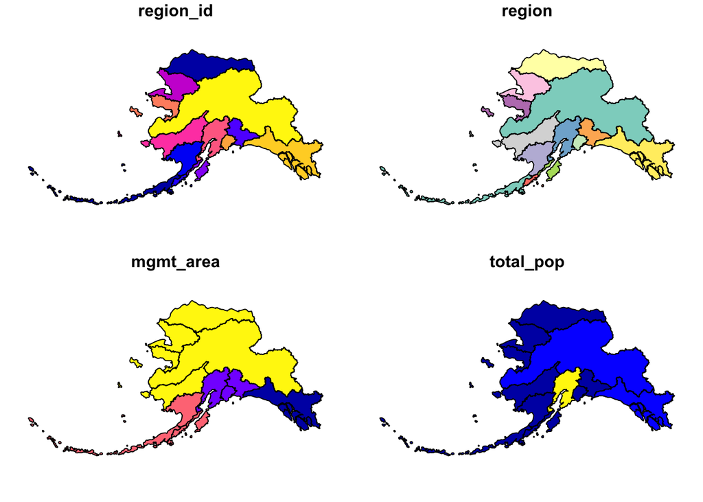

```r
pop_region_3338 <- left_join(ak_regions_3338, pop_region, by = "region")

plot(pop_region_3338)
```

how to use groupby and summarise to combing and summarize across geometries this dissolves boundaries of other factors

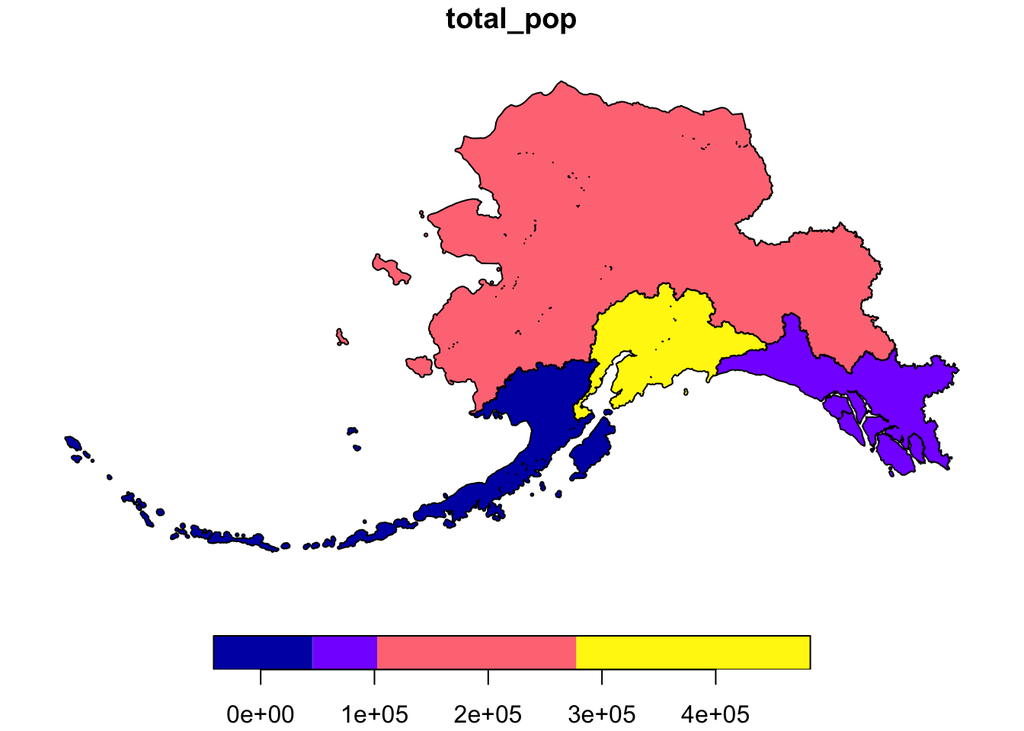

```r
pop_mgmt <- pop_region_3338 %>%
  group_by(mgmt_area) %>%
  summarise(total_pop = sum(total_pop))
  # summarise(total_pop = sum(total_pop), do_union = F) - this will keep the other boundaries, not dissolve
plot(pop_mgmt["total_pop"])
```

# Make Maps

```r
rivers_3338 <- read_sf("data/Shapefiles/ak_rivers_simp.shp")
st_crs(rivers_3338)
```

```
## Coordinate Reference System:
##   No EPSG code
##   proj4string: "+proj=aea +lat_1=55 +lat_2=65 +lat_0=50 +lon_0=-154 +x_0=0 +y_0=0 +ellps=GRS80 +units=m +no_defs"
```

we are going to match a bunch of dataframes: river-lines, community points, etc

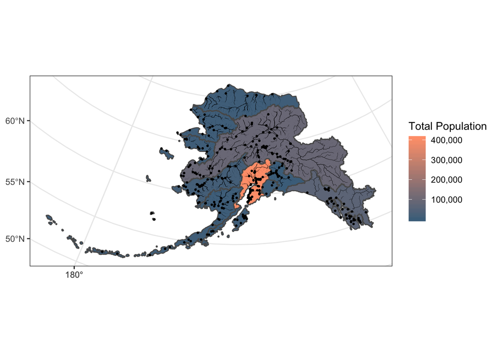

```r
ggplot() +
  geom_sf(data = pop_region_3338, mapping = aes(fill = total_pop)) +
  geom_sf(data = pop_3338, mapping = aes(), size = 0.5) +
  geom_sf(data = rivers_3338, mapping = aes(size = StrOrder), color = "black") +
  scale_size(range = c(0.01, 0.2), guide = F) +
  theme_bw() +
  labs(fill = "Total Population") +
  scale_fill_continuous(low = "skyblue4", high = "lightsalmon", labels = comma) #general custom color gradient
```